# Fake News Detection Using NLP

## Introduction

The spread of fake news and misinformation nowadays is a problem that needs to be addressed. There has been many efforts in developing models and methods to detect and classify fake news using Natural Language Processing (NLP). In this research report, we will be exploring two different text analysis methods for fake news detection using real-world data sets. We aim to compare two models: one model using classic machine learning techniques, such as logistic regression with TF-IDF and word embeddings, and another theory-driven model, based on sentiment analysis, humor detection, and satire detection.

We also used humor and satire detection in this model to differentiate between satirical content from real news. Fake news, particularly satirical news, intentionally incorporates cues that reveal its deceptive nature (Rubin et al., 2016). In their study, Rubin et al. (2016) rely on key linguistic features of satire, such as absurdity and humor, to detect incongruities and opposing scripts within the text. Satirical articles typically have a structure that mimics real news, but the introduction of absurd or incongruent entities in the final sentence serves as a punchline, signaling the satirical nature of the piece (Rubin et al., 2016). Humor is detected by identifying a significant semantic distance between the lead sentence (the opening of the article) and the final sentence, which often serves as the punchline in satirical news: humor arises from an unexpected shift in the narrative or meaning between the beginning and end of the text (Rubin et al., 2016). By incorporating these features in our model, we aim to detect potentially deceptive or misleading information.

Not only do we aim to achieve a high prediction accuracy, but we also aim to demonstrate the broader applicability of these models across different domains to showcase their adaptability and robustness.

## Method & Results

The required libraries were all loaded into RStudio first.

```r
library(quanteda)
library(readr)
library(caret)
library(glmnet)
library(ggplot2)
library(reticulate)
library(dplyr)
library(reshape2)
library(ggrepel)
library(quanteda.textstats)
library(tidyr)
library(ggiraph, verbose=F)
library(ggwordcloud)
library(stringr)
```

```python
import re
import pandas as pd
import spacy
from nltk.sentiment import SentimentIntensityAnalyzer
from sklearn.model_selection import train_test_split
from sklearn.feature_extraction.text import CountVectorizer, TfidfVectorizer
from sklearn.linear_model import LogisticRegression
from sklearn.preprocessing import StandardScaler
from sklearn.metrics import accuracy_score
import numpy as np
from sklearn.metrics.pairwise import cosine_similarity
from nltk.tokenize import sent_tokenize
from sklearn.metrics import accuracy_score
from sklearn.model_selection import cross_val_score
import nltk
import matplotlib
import matplotlib.pyplot as plt
from matplotlib.patches import Wedge
import seaborn as sns
from sklearn.metrics import classification_report, precision_score, recall_score, f1_score, confusion_matrix
from matplotlib.patches import FancyBboxPatch
from wordcloud import WordCloud
from PIL import Image
```

### The Data Set

The data set we used contained three columns: `id`, `tweet`, and `label (fake/real)`.

```r
df<-read.csv("psych-data-science-lab-bgu-2024/train.csv")
```

```python
df_train = pd.read_csv("psych-data-science-lab-bgu-2024/train.csv")
```

### Model 1

#### Data Pre-processing

To prepare the data for modeling, we pre-processed the text. This included removing URLs, mentions, hash tags, numbers, punctuation, and special characters. The text was also converted to lowercase to ensure consistency.

```python
def clean_text(text):
    text = re.sub(r'http\S+|www\S+|https\S+', '', text, flags=re.MULTILINE)
    text = re.sub(r'\@\w+|\#\w+|\d+', '', text)
    text = re.sub(r'[^\w\s]', '', text)
    text = text.lower()
    return text
df_train['tweet'] = df_train['tweet'].apply(clean_text)
```

#### Feature Extraction

We extracted the following features from the tweets:

1. **Sentiment Scores:** by using the NLTK Sentiment Intensity Analyzer, we extracted sentiment scores (`positive`, `negative`, `neutral`, and `compound`). The `compound` sentiment score was computed because it provides a holistic measure of the overall sentiment in the text. It is a single value that aggregates the sentiments into a single, normalized score that ranges from -1 (extremely negative) to +1 (extremely positive). This is particularly effective when the tweets are short and contain mixed sentiments. Then, the features were prepared.

   ```python
   nltk.download('vader_lexicon')
   ```

   ```
   True
   ```

   ```python
   nlp = spacy.load('en_core_web_sm')
   sia = SentimentIntensityAnalyzer()
   df_train['positive'] = df_train['tweet'].apply(lambda x: sia.polarity_scores(x)['pos'])
   df_train['negative'] = df_train['tweet'].apply(lambda x: sia.polarity_scores(x)['neg'])
   df_train['neutral'] = df_train['tweet'].apply(lambda x: sia.polarity_scores(x)['neu'])
   df_train['compound'] = df_train['tweet'].apply(lambda x: sia.polarity_scores(x)['compound'])
   ```

   Now that we’ve extracted the sentiments, let’s calculate the overall sentiment score for each news group (fake/real). For real tweets, the gauge shows the average positive and negative sentiment across all tweets labeled as “real”. For fake tweets, the gauge shows the average positive and negative sentiment across all tweets labeled as “fake”. The arrow in the sentiment gauge points to the balance between positive and negative sentiment. It indicates how skewed the sentiment is towards either positive or negative, based on the ratio of positive sentiment to the total sentiment.

   ```python
   def plot_sentiment_gauge(positive, negative):
       fig, ax = plt.subplots(figsize=(8, 5))
       fig.patch.set_facecolor('#f5f9f3')
       ax.set_facecolor('#f5f9f3')
       wedges = [
           {'label': 'Negative', 'angle': 90, 'color': '#c7f8c7'},
           {'label': 'Positive', 'angle': 90, 'color': '#f8c7c7'}
       ]
       start_angle = 180
       for wedge in wedges:
           ax.add_patch(Wedge((0, 0), 1, start_angle, start_angle - wedge['angle'],
                              facecolor=wedge['color'], edgecolor='black', lw=2))
           start_angle -= wedge['angle']
       total_sentiment = positive + negative
       if total_sentiment == 0:
           sentiment_ratio = 0.5
       else:
           sentiment_ratio = positive / total_sentiment
       sentiment_angle = 180 - (sentiment_ratio * 180)
       arrow_length = 0.8
       arrow_dx = arrow_length * np.cos(np.radians(sentiment_angle))
       arrow_dy = arrow_length * np.sin(np.radians(sentiment_angle))
       ax.arrow(0, 0, arrow_dx, arrow_dy, head_width=0.05, head_length=0.1, fc='gray', ec='gray', lw=2)
       ax.text(-0.9, 0.05, 'Negative', horizontalalignment='center', verticalalignment='center', fontsize=10, color='#4a4a4a')
       ax.text(0.9, 0.05, 'Positive', horizontalalignment='center', verticalalignment='center', fontsize=10, color='#4a4a4a')
       ax.text(0, -0.3, f'Positive={positive:.2f}, Negative={negative:.2f}',
               horizontalalignment='center', verticalalignment='center', fontsize=12, fontweight='bold', color='#4a4a4a')
       ax.set_xlim([-1, 1])
       ax.set_ylim([0, 1])
       ax.set_aspect('equal')
       ax.axis('off')
       plt.tight_layout()

       plt.show()
   ```

   ```python
   real_tweets = df_train[df_train['label'] == 'real']
   fake_tweets = df_train[df_train['label'] == 'fake']
   real_positive = real_tweets['positive'].mean()
   real_negative = real_tweets['negative'].mean()
   fake_positive = fake_tweets['positive'].mean()
   fake_negative = fake_tweets['negative'].mean()
   print("Real Tweets Sentiment")
   ```

   ```
   Real Tweets Sentiment
   ```

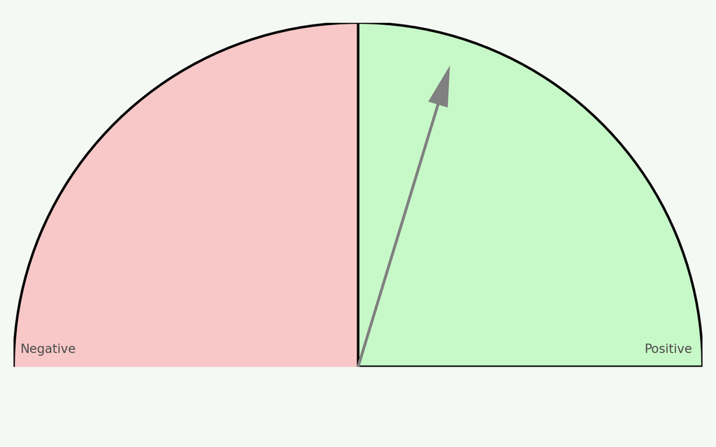

   ```python
   plot_sentiment_gauge(real_positive, real_negative)
   ```

   ```python
   print("Fake Tweets Sentiment")
   ```

   ```
   Fake Tweets Sentiment
   ```

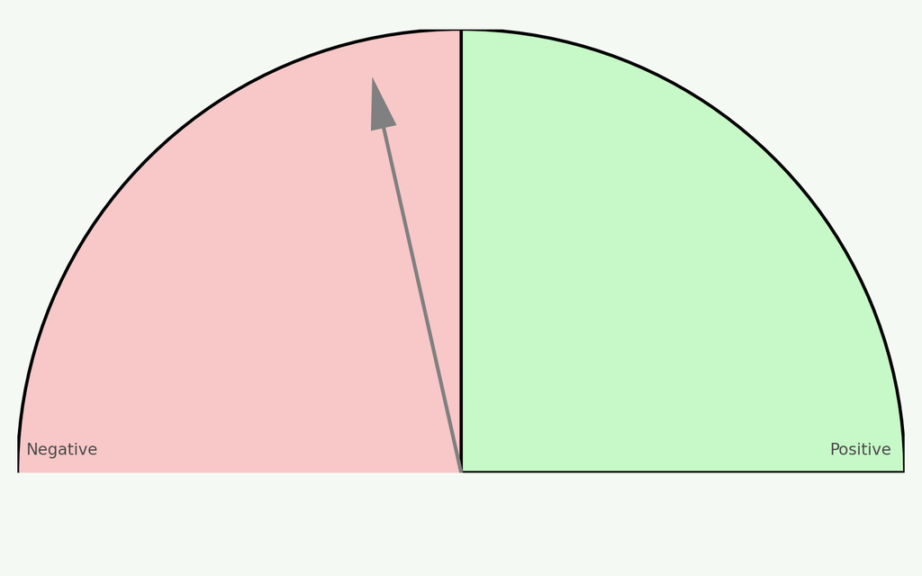

   ```python
   plot_sentiment_gauge(fake_positive, fake_negative)
   ```

   As can be seen in the plots, it looks like that the fake news overall sentiment is negative, while the overall real news sentiment is positive. However, the effect seems to be small.
2. **Absurdity Detection:** The text was first tokenized (broken down into smaller units, allowing the algorithm to work with a structured input) into sentences, words, and named entities (like people, locations, or organizations). Absurdity was detected by checking if new entities are introduced in the last sentence of a tweet.

   ```python
   def detect_absurdity(text):
       doc = nlp(text)
       sentences = list(doc.sents)  #spaCy for sentence tokenization
       all_entities = set([ent.text for ent in doc.ents])

       if len(sentences) > 1:
           last_sentence = sentences[-1].text  #the last sentence as text
           last_sentence_doc = nlp(last_sentence)
           last_entities = set([ent.text for ent in last_sentence_doc.ents])

           #is the last sentence new?
           if last_entities and not last_entities.issubset(all_entities - last_entities):
               return 1  #if absurd
       return 0  #if not absurd
   ```

   ```python
   df_train['absurdity'] = df_train['tweet'].apply(detect_absurdity)
   ```

   ```python
   real_news = df_train[df_train['label'] == 'real']
   fake_news = df_train[df_train['label'] == 'fake']
   real_absurdity_mean = real_news['absurdity'].mean()
   fake_absurdity_mean = fake_news['absurdity'].mean()
   print(f"Mean Absurdity for Real News: {real_absurdity_mean}")
   ```

   ```
   Mean Absurdity for Real News: 0.01048171275646744
   ```

   ```python
   print(f"Mean Absurdity for Fake News: {fake_absurdity_mean}")
   ```

   ```
   Mean Absurdity for Fake News: 0.0036800785083415115
   ```

   On average, real news tweets have an absurdity score of 0.01. This score is a measure of how often a tweet exhibits absurdity based on the function we defined (i.e., the last sentence introducing new information compared to the rest of the tweet). The mean absurdity for fake news is 0.003, which is even lower than for real news. This suggests that fake news tweets, on average, exhibit fewer characteristics of absurdity.
3. **Humor Detection:** Humor was estimated by calculating the cosine similarity between the first and last sentences of each tweet. Low similarity indicates potential humor. The text was tokenized first here too.

   ```python
   def detect_humor(text):
       doc = nlp(text)
       sentences = [sent.text for sent in doc.sents]
       if len(sentences) < 2:
           return 0
       first_sentence = sentences[0]
       last_sentence = sentences[-1]
       vectorizer = TfidfVectorizer().fit([first_sentence, last_sentence])
       vectors = vectorizer.transform([first_sentence, last_sentence])
       similarity = cosine_similarity(vectors[0], vectors[1])[0][0]
       return 1 if similarity < 0.5 else 0
   ```

   ```python
   df_train['humor'] = df_train['tweet'].apply(detect_humor)
   ```

   The mean humor score for real news (0.026) is higher than for fake news (0.018; this calculation is shown in the jupyter notebook as there were some issues calculating it on RStudio). This indicates that real news tweets tend to contain more elements that the function we defined identifies as humorous, although the difference is small. Both real and fake news have relatively low humor scores overall, indicating that humorous content is not highly prevalent in the data set (again, according to the function we defined).

#### Data Preparation & Feature Representation

The features were prepared for modeling and turned into arrays for easier manipulation and to ensure they are part of a single structure that the algorithm can understand. The data was split into training and test sets, using a 80/20 split.

```python
X = df_train[['tweet', 'positive', 'negative', 'neutral', 'compound', 'absurdity', 'humor']]
y = df_train['label']
X_train, X_val, y_train, y_val = train_test_split(X, y, test_size=0.2, random_state=42)
```

The features for each tweet were vectorized using the Bag-of-Words method: thinking about the text as a collection of tokens with different frequencies (Teitelbaum & Simchon, 2024). We used the countVectorizer to convert our collection of text documents into a matrix of token counts. This converts the text into a sparse matrix of numbers that an algorithm can understand. Here, each row is a tweet or document and each column is a specific word. The matrix values are the word counts in each document.

```python
vectorizer = CountVectorizer(max_features=5000, stop_words='english')
X_train_vec = vectorizer.fit_transform(X_train['tweet'])
X_val_vec = vectorizer.transform(X_val['tweet'])
```

```python
X_train_final = np.hstack([X_train_vec.toarray(), X_train[['positive', 'negative', 'neutral', 'compound', 'absurdity', 'humor']].values])
X_val_final = np.hstack([X_val_vec.toarray(), X_val[['positive', 'negative', 'neutral', 'compound', 'absurdity', 'humor']].values])
```

#### Model Training & Evaluation

We used logistic regression as the primary model for classification. We used Ridge regularization to add penalty and thus prevent overfitting. We used a `C` of 0.0001, heavily penalizing the model. This ensures that the model does not give too much importance to irrelevant features.

The feature vectors were standardized using `StandardScaler`, and the model was trained on the scaled training data with a cross-validation of 10 folds.

```python
scaler = StandardScaler()
X_train_final_scaled = scaler.fit_transform(X_train_final)
X_val_final_scaled = scaler.transform(X_val_final)
```

```python
model = LogisticRegression(max_iter=1000, C=0.0001)
model.fit(X_train_final_scaled, y_train)
```

```
LogisticRegression(C=0.0001, max_iter=1000)
```

```python
#prediction on validation set
y_pred_val = model.predict(X_val_final_scaled)
#calculating validation accuracy
val_accuracy = accuracy_score(y_val, y_pred_val)
```

The model was evaluated on the validation set using accuracy as the metric. We also calculated the training accuracy and cross-validation scores to check the model’s generalization performance.

```python
print(f'Validation Accuracy: {val_accuracy}')
```

```
Validation Accuracy: 0.9112149532710281
```

```python
y_pred_train = model.predict(X_train_final_scaled)
train_accuracy = accuracy_score(y_train, y_pred_train)
print(f'Training Accuracy: {train_accuracy}')
```

```
Training Accuracy: 0.9566296728971962
```

```python
cv_scores = cross_val_score(model, X_train_final_scaled, y_train, cv=10)
print(f'Cross-Validation Mean Accuracy: {cv_scores.mean()}')
```

```
Cross-Validation Mean Accuracy: 0.913988346779357
```

```python
cm = confusion_matrix(y_val, y_pred_val)
print("Confusion Matrix:")
```

```
Confusion Matrix:
```

```python
print(cm)
```

```
[[751  65]
 [ 87 809]]
```

```python
precision = precision_score(y_val, y_pred_val, average='weighted')
recall = recall_score(y_val, y_pred_val, average='weighted')
f1 = f1_score(y_val, y_pred_val, average='weighted')

print(f'Precision: {precision}')
```

```
Precision: 0.9115933726285819
```

```python
print(f'Recall: {recall}')
```

```
Recall: 0.9112149532710281
```

```python
print(f'F1-Score: {f1}')
```

```
F1-Score: 0.9112536506660184
```

```python
print("\nClassification Report:")
```

```
Classification Report:
```

```python
print(classification_report(y_val, y_pred_val, target_names=['Fake', 'Real']))
```

```
              precision    recall  f1-score   support

        Fake       0.90      0.92      0.91       816
        Real       0.93      0.90      0.91       896

    accuracy                           0.91      1712
   macro avg       0.91      0.91      0.91      1712
weighted avg       0.91      0.91      0.91      1712
```

The model achieved a training accuracy of approximately 0.96, which means that the model has learned well from the data. The validation accuracy is over 0.91: this shows that the model can generalize well to unseen data without overfitting. The cross-validation achieved an average accuracy of 91.40% across different splits of the data set. This helped ensure that the model’s performance is consistent and not overly reliant on the specific training/validation split. The small difference between the training and the validation accuracy suggests a reasonable balance between bias and variance.

The performance of the model was also evaluated using other metrics, including precision, recall, and F1-score. Precision measures the percentage of correctly predicted positive observations out of all predicted positives. In our case, 0.91 of the predictions labeled as “fake” or “real” were correct. Recall measures the percentage of actual positive cases that were correctly identified. The model correctly identified 0.91 of the actual “fake” and “real” cases. The F1-score is the harmonic mean of precision and recall. the F1-score is 0.91, which indicates a strong balance between precision and recall.

Overall, the model shows a robust performance with high precision, recall, and F1-scores across both classes. Given the overall accuracy of 0.91, we can say that this model performs well for the task of fake news detection.

To better understand the model, we wanted to see which features contribute most to the prediction.

```python
vectorizer_feature_names = vectorizer.get_feature_names_out()
all_feature_names = np.concatenate([vectorizer_feature_names, ['positive', 'negative', 'neutral', 'compound', 'absurdity', 'humor']])
coefficients = model.coef_[0]
feature_importance = pd.DataFrame({
    'Feature': all_feature_names,
    'Coefficient': coefficients
})
feature_importance['Absolute Coefficient'] = feature_importance['Coefficient'].abs()
feature_importance_sorted = feature_importance.sort_values(by='Absolute Coefficient', ascending=False)
print(feature_importance_sorted.head(10))
```

```
          Feature  Coefficient  Absolute Coefficient
1046  coronavirus    -0.051400              0.051400
611         cases     0.046090              0.046090
4510        total     0.036018              0.036018
4608        trump    -0.032804              0.032804
4424        tests     0.032325              0.032325
4486        today     0.032079              0.032079
2920          new     0.031632              0.031632
2965       number     0.030282              0.030282
3701     reported     0.030239              0.030239
4210       states     0.029526              0.029526
```

the positive coefficients here push the prediction toward the positive class, real news, while the negative coefficients push it toward the negative class, fake news. The larger the magnitude of the coefficient, the more strongly that word influences the classification.

```python
cloud_image_path = 'cloudbackground.png'
cloud_image = Image.open(cloud_image_path)
cloud_image_np = np.array(cloud_image)

cloud_mask = cloud_image_np[:, :, 3]
cloud_mask_binary = np.where(cloud_mask > 128, 255, 0).astype(np.uint8)  # Binary mask
top_features = feature_importance_sorted.head(10)
word_frequencies = {feature: abs(coef) for feature, coef in zip(top_features['Feature'], top_features['Coefficient'])}
def color_func(word, font_size, position, orientation, random_state=None, **kwargs):
    coef = top_features.loc[top_features['Feature'] == word, 'Coefficient'].values[0]
    if coef > 0:
        return "rgb(120, 200, 120)"
    else:
        return "rgb(230, 150, 150)"
wordcloud = WordCloud(background_color='rgb(245, 245, 245)', mask=cloud_mask_binary, contour_color='black',
                      max_words=10, max_font_size=200, color_func=color_func).generate_from_frequencies(word_frequencies)
plt.figure(figsize=(10, 10))
plt.imshow(cloud_image_np[:, :, :3], interpolation='bilinear')
plt.imshow(wordcloud, interpolation='bilinear', alpha=0.8)
plt.axis('off')
```

```
(-0.5, 359.5, 359.5, -0.5)
```

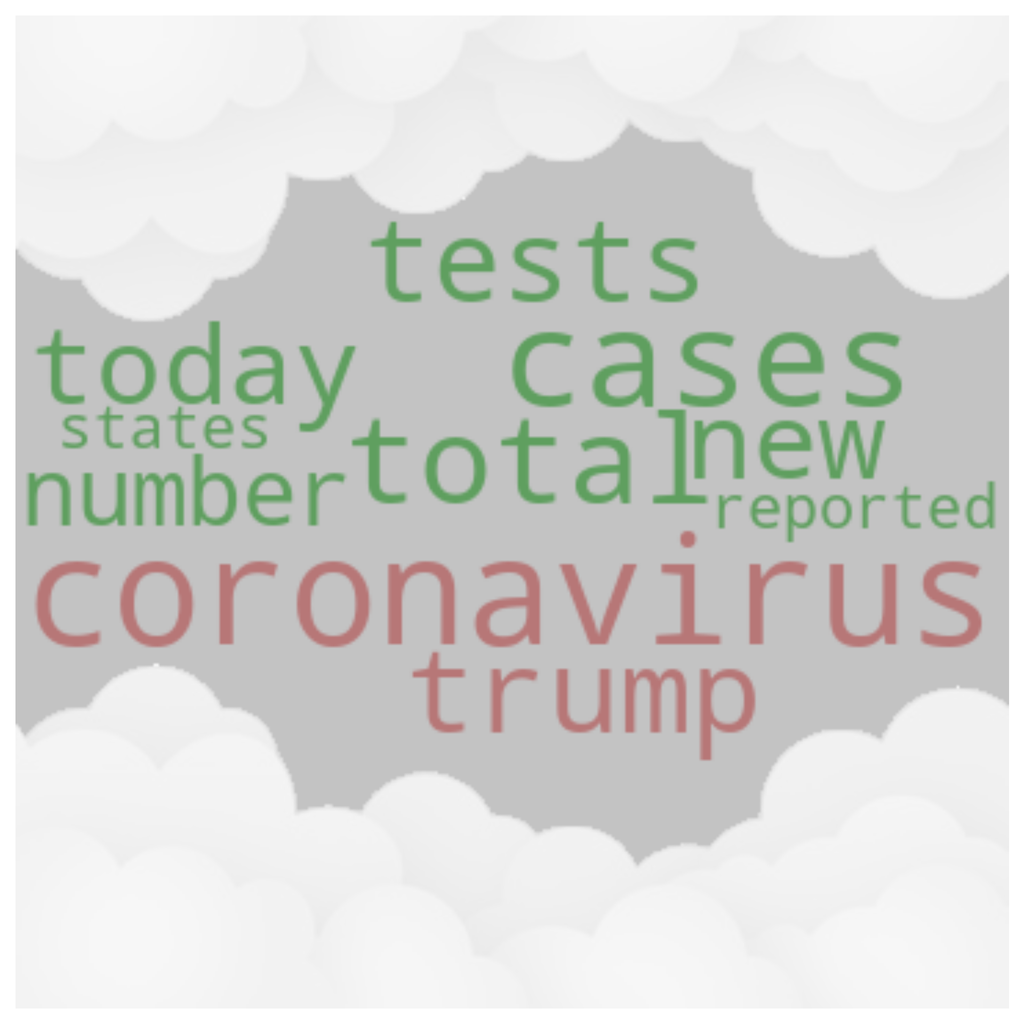

```python
plt.tight_layout()
plt.show()
```

Here, the red words represent the negative coefficients, and are associated with fake news. The green words, on the other hand, represent the positive coefficients, and are associated with real news.

#### Generalization to New Data

To evaluate how our first model generalizes to other domains, we tested our models using a different openly-available data set. This is also a data set that contains fake and real news, and it was found on Kaggle (see bibliography). The data set contains five columns: `title`, `text`, `subject (world news/politics news)`, `date`, and `label`. Before reading the data, we made sure to remove the dates from the text’s body. The same method and model were applied here.

```python
df_train1 = pd.read_csv("new_dataset.csv")
df_train1['text'] = df_train1['text'].apply(clean_text)
```

```python
nltk.download('vader_lexicon')
```

```
True
```

```python
nlp = spacy.load('en_core_web_sm')
sia = SentimentIntensityAnalyzer()
df_train1['positive'] = df_train1['text'].apply(lambda x: sia.polarity_scores(x)['pos'])
df_train1['negative'] = df_train1['text'].apply(lambda x: sia.polarity_scores(x)['neg'])
df_train1['neutral'] = df_train1['text'].apply(lambda x: sia.polarity_scores(x)['neu'])
df_train1['compound'] = df_train1['text'].apply(lambda x: sia.polarity_scores(x)['compound'])
```

```python
df_train1['absurdity'] = df_train1['text'].apply(detect_absurdity)
df_train1['humor'] = df_train1['text'].apply(detect_humor)
```

```python
X1 = df_train1[['text', 'positive', 'negative', 'neutral', 'compound', 'absurdity', 'humor']]
y1 = df_train1['label']
X_train1, X_val1, y_train1, y_val1 = train_test_split(X1, y1, test_size=0.2, random_state=42)
```

```python
vectorizer = CountVectorizer(max_features=5000, stop_words='english')
X_train_vec1 = vectorizer.fit_transform(X_train1['text'])
X_val_vec1 = vectorizer.transform(X_val1['text'])
X_train_final1 = np.hstack([X_train_vec1.toarray(), X_train1[['positive', 'negative', 'neutral', 'compound', 'absurdity', 'humor']].values])
X_val_final1 = np.hstack([X_val_vec1.toarray(), X_val1[['positive', 'negative', 'neutral', 'compound', 'absurdity', 'humor']].values])
```

```python
scaler = StandardScaler()
X_train_final_scaled1 = scaler.fit_transform(X_train_final1)
X_val_final_scaled1 = scaler.transform(X_val_final1)
model1 = LogisticRegression(max_iter=1000, C=0.0001)
model.fit(X_train_final_scaled1, y_train1)
```

```
LogisticRegression(C=0.0001, max_iter=1000)
```

```python
y_pred_val1 = model.predict(X_val_final_scaled1)
val_accuracy1 = accuracy_score(y_val1, y_pred_val1)
print(f'Validation Accuracy: {val_accuracy1}')
```

```
Validation Accuracy: 0.949
```

```python
y_pred_train1 = model.predict(X_train_final_scaled1)
train_accuracy1 = accuracy_score(y_train1, y_pred_train1)
print(f'Training Accuracy: {train_accuracy1}')
```

```
Training Accuracy: 0.97575
```

```python
cv_scores1 = cross_val_score(model1, X_train_final_scaled1, y_train1, cv=10)
print(f'Cross-Validation Mean Accuracy: {cv_scores1.mean()}')
```

```
Cross-Validation Mean Accuracy: 0.9567499999999999
```

As we can see, the model has a strong performance with high training and validation accuracy, as well as consistent results across multiple folds in cross-validation. The model achieved an overall accuracy of 95%, meaning that 95% of the predictions were correct across both classes.

```python
cm1 = confusion_matrix(y_val1, y_pred_val1)
print("Confusion Matrix:")
```

```
Confusion Matrix:
```

```python
print(cm1)
```

```
[[466  34]
 [ 17 483]]
```

```python
precision1 = precision_score(y_val1, y_pred_val1, average='weighted')
recall1 = recall_score(y_val1, y_pred_val1, average='weighted')
f11 = f1_score(y_val1, y_pred_val1, average='weighted')

print(f'Precision: {precision}')
```

```
Precision: 0.9115933726285819
```

```python
print(f'Recall: {recall}')
```

```
Recall: 0.9112149532710281
```

```python
print(f'F1-Score: {f1}')
```

```
F1-Score: 0.9112536506660184
```

```python
print("\nClassification Report:")
```

```
Classification Report:
```

```python
print(classification_report(y_val1, y_pred_val1, target_names=['Fake', 'Real']))
```

```
              precision    recall  f1-score   support

        Fake       0.96      0.93      0.95       500
        Real       0.93      0.97      0.95       500

    accuracy                           0.95      1000
   macro avg       0.95      0.95      0.95      1000
weighted avg       0.95      0.95      0.95      1000
```

### Model 2

#### Data Pre-processing

The tweets were processed to create tokens from the raw text. This involved corpus creation, which is the main structure used for text analysis. A corpus is a collection of text documents along with the attributes associated with each document (Teitelbaum & Simchon, 2024). Then, the corpus was tokenized by removing punctuation, symbols, and URLs, converting all text to lowercase, and removing stop words (because they don’t contribute to meaning). Tokens with fewer than two characters were also removed.

```r
df$label <- ifelse(df$label == 'fake', 0, 1)
corpus <- corpus(df$tweet)
tokens <- tokens(corpus,
                 remove_punct = TRUE,
                 remove_symbols = TRUE,
                 remove_url = TRUE) |>
  tokens_tolower() |>
  tokens_remove(stopwords("en")) |>
  tokens_keep(min_nchar = 2)
```

#### Feature Extraction: TF-IDF

To convert the processed text into numerical features for the model, a document-feature matrix (DFM) was created from the tokens, where each tweet was represented by a vector of word counts (features). Then, the DFM was transformed into a term frequency-inverse document frequency (TF-IDF) matrix, which adjusts the word counts based on how frequently they appear across the data set. this will result in a table where each row is a document and each column is a feature (Teitelbaum & Simchon, 2024).

```r
dfm <- dfm(tokens)
dfm_tfidf <- dfm_tfidf(dfm)
```

To see which words were more common in each tweet category, we generated the following plot:

```r
df <- read.csv("psych-data-science-lab-bgu-2024/train.csv")
fake_vs_real<- dfm |> textstat_frequency(groups=df$label)
fake_vs_real <- fake_vs_real |>
  filter(group %in% c("fake", "real")) |>
  pivot_wider(id_cols = "feature",
              names_from = "group",
              values_from = "frequency",
              names_prefix = "count_") |>
  mutate(freq_fake = count_fake/sum(count_fake, na.rm = TRUE),
         freq_real = count_real/sum(count_real, na.rm = TRUE),
         label_freq_ratio = freq_fake/freq_real)
#rotated F/F plot----
set.seed(2023)
p <- fake_vs_real |>
  mutate(
    common = (freq_fake + freq_real)/2,
    feature = str_replace_all(feature, "'", "`")) |>
  ggplot(aes(label_freq_ratio, common,
             label = feature,
             color = label_freq_ratio,
             tooltip = feature,
             data_id = feature
  )) +
  geom_point_interactive() +
  geom_text_repel_interactive(size = 2) +
  scale_y_continuous(
    trans = "log2", breaks = ~.x,
    minor_breaks = ~2^(seq(0, log2(.x[2]))),
    labels = c("Rare", "Common")
  ) +
  scale_x_continuous(
    trans = "log10", limits = c(1/10,10),
    breaks = c(1/10, 1, 10),
    labels = c("10x More Common\nin Real Tweets",
               "Equal Proportion",
               "10x More Common\nin Fake Tweets")
  ) +
  scale_color_gradientn(
    colors = c("#E2E2E2", "#88b97e", "#4a4a4a", "#f4a4a4", "#9B59A7"),
    trans = "log2",
    guide = "none"
  ) +
  labs(
    title = "Words in fake and real tweets",
    x = "",
    y = "Total Frequency",
    color = ""
  ) +
  coord_fixed(ratio = 1/8) +
  theme_minimal() +
  theme(
    plot.title = element_text(size = 16, face = "bold", color = "#88b97e"),
    axis.text = element_text(color = "#4a4a4a"),
    panel.grid.major = element_line(color = "#f4a4a4"),
    panel.grid.minor = element_blank(),
    panel.background = element_rect(fill = "#eaf4e2"),
    plot.background = element_rect(fill = "#eaf4e2")
  )
girafe_options(
  girafe(ggobj = p),
  opts_tooltip(css = "font-family:sans-serif;font-size:1em;color:Black;")
)
```

[interactive chart not shown]

#### Model Training

The data set was split into a training set and a test set (80/20 split as well) to evaluate the model’s performance on new data.

To classify the tweets as fake or real, a logistic regression model with Elastic Net regularization was trained using a 10 fold cross-validation. Elastic Net combines Lasso and Ridge regularization, which helps the model generalize better and prevent overfitting by penalizing large coefficients that may be mistaken to be important. The optimal value of the regularization parameter (lambda) was chosen using cross-validation.

```r
set.seed(123)
df$label <- ifelse(df$label == 'fake', 0, 1)
trainIndex <- createDataPartition(df$label, p = 0.8, list = FALSE, times = 1)
train_data <- dfm_tfidf[trainIndex, ]
test_data  <- dfm_tfidf[-trainIndex, ]
train_labels <- df$label[trainIndex]
test_labels  <- df$label[-trainIndex]
```

```r
train_control <- trainControl(method = "cv", number = 10)
model <- cv.glmnet(as(train_data, "dgCMatrix"), train_labels,
                   family = "binomial", alpha = 0.5,
                   lambda = 10^seq(2, -2, by = -0.1))
```

```r
train_predictions <- predict(model, newx = as(train_data, "dgCMatrix"), s = "lambda.min")
train_accuracy <- mean((train_predictions > 0.5) == train_labels)
paste("Training Accuracy:", round(train_accuracy * 100, 2), "%")
```

```
[1] "Training Accuracy: 94.61 %"
```

```r
test_predictions <- predict(model, newx = as(test_data, "dgCMatrix"), s = "lambda.min")
test_accuracy <- mean((test_predictions > 0.5) == test_labels)
paste("Validation Accuracy:", round(test_accuracy * 100, 2), "%")
```

```
[1] "Validation Accuracy: 90.13 %"
```

```r
test_predictions_prob <- as.numeric(test_predictions)
test_predictions_binary <- ifelse(test_predictions_prob > 0.5, 1, 0)
predictions_factor <- factor(test_predictions_binary, levels = c(0, 1))
test_labels_factor <- factor(test_labels, levels = c(0, 1))
accuracy_metrics <- confusionMatrix(predictions_factor, test_labels_factor, positive = "1")
accuracy_metrics
```

```
Confusion Matrix and Statistics

          Reference
Prediction   0   1
         0 773 148
         1  21 770

               Accuracy : 0.9013
                 95% CI : (0.8862, 0.915)
    No Information Rate : 0.5362
    P-Value [Acc > NIR] : < 2.2e-16

                  Kappa : 0.8037

 Mcnemar's Test P-Value : < 2.2e-16

            Sensitivity : 0.8388
            Specificity : 0.9736
         Pos Pred Value : 0.9735
         Neg Pred Value : 0.8393
             Prevalence : 0.5362
         Detection Rate : 0.4498
   Detection Prevalence : 0.4620
      Balanced Accuracy : 0.9062

       'Positive' Class : 1
```

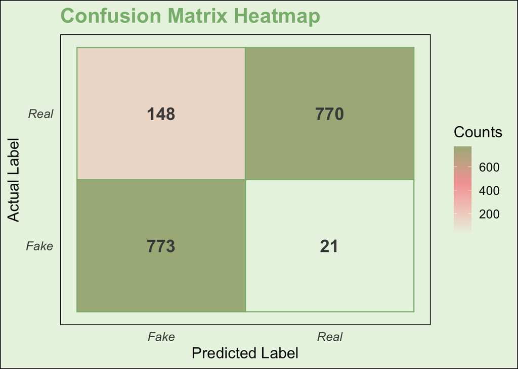

```r
confusion_matrix <- as.matrix(accuracy_metrics$table)
confusion_matrix_df <- melt(confusion_matrix)
confusion_matrix_df$Reference <- ifelse(confusion_matrix_df$Reference == 0, "Fake", "Real")
confusion_matrix_df$Prediction <- ifelse(confusion_matrix_df$Prediction == 0, "Fake", "Real")
ggplot(confusion_matrix_df, aes(x = Prediction, y = Reference, fill = value)) +
  geom_tile(color = "#88b97e", linewidth = 0.5) +  # Tile border
  geom_text(aes(label = value), color = "#4a4a4a", size = 6, fontface = "bold") +
  scale_fill_gradient2(
    low = "#eaf4e2",
    mid = "#f4a4a4",
    high = "#88b97e",
    midpoint = median(confusion_matrix_df$value),
    name = "Counts"
  ) +
  theme_minimal(base_size = 15) +
  labs(title = "Confusion Matrix Heatmap", x = "Predicted Label", y = "Actual Label") +
  theme(
    plot.title = element_text(size = 20, face = "bold", color = "#88b97e"),
    axis.text.x = element_text(face = "italic", color = "#4a4a4a"),
    axis.text.y = element_text(face = "italic", color = "#4a4a4a"),
    panel.grid.major = element_blank(),
    panel.grid.minor = element_blank(),
    legend.position = "right",
    panel.background = element_rect(fill = "#eaf4e2"),
    plot.background = element_rect(fill = "#eaf4e2")
  )
```

#### Generalization to New Data

To evaluate how our second model generalizes to other domains, we tested our models using the same data set we used above to generalize our first model. The same method and model were applied here.

```r
df1 <- read.csv("new_dataset.csv")
df1$label <- ifelse(df1$label == 'fake', 0, 1)
```

```r
corpus1 <- corpus(df1$text)
tokens1 <- tokens(corpus1,
                 remove_punct = TRUE,
                 remove_symbols = TRUE,
                 remove_url = TRUE) |>
  tokens_tolower() |>
  tokens_remove(stopwords("en")) |>
  tokens_keep(min_nchar = 2)
```

```r
dfm1 <- dfm(tokens1)
dfm_tfidf1 <- dfm_tfidf(dfm1)
```

```r
set.seed(123)
trainIndex1 <- createDataPartition(df1$label, p = 0.8, list = FALSE, times = 1)
train_data1 <- dfm_tfidf1[trainIndex1, ]
test_data1  <- dfm_tfidf1[-trainIndex1, ]
train_labels1 <- df1$label[trainIndex1]
test_labels1  <- df1$label[-trainIndex1]
```

```r
train_control <- trainControl(method = "cv", number = 10)
model1 <- cv.glmnet(as(train_data1, "dgCMatrix"), train_labels1,
                   family = "binomial", alpha = 0.5, lambda = 10^seq(2, -2, by = -0.1))
train_predictions1 <- predict(model1, newx = as(train_data1, "dgCMatrix"), s = "lambda.min")
train_accuracy1 <- mean((train_predictions1 > 0.5) == train_labels1)
```

```r
paste("Training Accuracy:", round(train_accuracy1 * 100, 2), "%")
```

```
[1] "Training Accuracy: 99.62 %"
```

```r
test_predictions1 <- predict(model1, newx = as(test_data1, "dgCMatrix"), s = "lambda.min")
test_accuracy1 <- mean((test_predictions1 > 0.5) == test_labels1)
paste("Validation Accuracy:", round(test_accuracy1 * 100, 2), "%")
```

```
[1] "Validation Accuracy: 97.4 %"
```

```r
test_predictions_prob1 <- as.numeric(test_predictions1)
test_predictions_binary1 <- ifelse(test_predictions_prob1 > 0.5, 1, 0)
predictions_factor1 <- factor(test_predictions_binary1, levels = c(0, 1))
test_labels_factor1 <- factor(test_labels1, levels = c(0, 1))
accuracy_metrics1 <- confusionMatrix(predictions_factor1, test_labels_factor1, positive = "1")
accuracy_metrics1
```

```
Confusion Matrix and Statistics

          Reference
Prediction   0   1
         0 492  18
         1   8 482

               Accuracy : 0.974
                 95% CI : (0.9621, 0.9829)
    No Information Rate : 0.5
    P-Value [Acc > NIR] : < 2e-16

                  Kappa : 0.948

 Mcnemar's Test P-Value : 0.07756

            Sensitivity : 0.9640
            Specificity : 0.9840
         Pos Pred Value : 0.9837
         Neg Pred Value : 0.9647
             Prevalence : 0.5000
         Detection Rate : 0.4820
   Detection Prevalence : 0.4900
      Balanced Accuracy : 0.9740

       'Positive' Class : 1
```

The model achieved a very high training accuracy of 0.99 on the new data set, indicating that it performed exceptionally well on the training data, correctly classifying nearly all instances! The model generalizes very well to unseen data, correctly predicting the labels for approximately 0.97 of the validation set.

The model achieved a high accuracy of 0.97, meaning the majority of predictions were correct. The class-specific metrics are all high as well. The model demonstrates outstanding performance with high accuracy, precision, recall, and balanced accuracy. The metrics show that the model is both precise and sensitive in detecting positive and negative cases, indicating that it is well-suited to deploy in real world scenarios.

## Discussion

Our results indicate that both models performed well in fake news detection. The first model focused on emotional and satirical cues, incorporating sentiment, absurdity, and humor detection. The results showed that fake news tweets had a more negative sentiment on average, while real news tweets displayed more positivity. In addition, fake news tended to score lower on absurdity and humor, indicating that real news tends to contain slightly more humorous or incongruent elements, which is not what we expected. Despite these small differences, the overall sentiment and humor scores were relatively low for both real and fake news, suggesting that these features may have a small impact in distinguishing between the two categories for the data set we used.

Both models achieved strong performance metrics, including precision, recall, and F1-scores. However, the first model’s reliance on theory-driven features adds a unique perspective by focusing on the qualitative aspects of the text rather than the quantitative measures. This suggests that while traditional machine learning models can help in numerical accuracy, a theory-driven approach can provide deeper insights into the mechanisms behind misinformation and its emotional impact on audiences.

The findings of this study have important implications for developing tools to prevent misinformation and fake news. The performance of both models indicates that employing diverse methodologies (combining traditional NLP techniques with theory-driven insights) can enhance the effectiveness of fake news detection models. Future research could expand on this work by exploring additional linguistic features, examining the role of user interactions in spreading misinformation, and testing these models in real world scenarios.

In conclusion, both the theory-driven model and the traditional machine learning model provide valuable contributions to the field of fake news detection.

## Bibliography

Teitelbaum, L., & Simchon, A. (2024). Data Science for Psychology: Natural Language. https://zenodo.org/doi/10.5281/zenodo.10908366

Chakraborty, K., Bhatia, S., Bhattacharyya, S., Platos, J., Bag, R., & Hassanien, A. E. (2020). Sentiment analysis of covid-19 tweets by deep learning classifiers—a study to show how popularity is affecting accuracy in social media. *Applied Soft Computing*, *97*, 106754. https://doi.org/10.1016/j.asoc.2020.106754

Rubin, V., Conroy, N., Chen, Y., & Cornwell, S. (2016). Fake news or truth? using satirical cues to detect potentially misleading news. *Proceedings of the Second Workshop on Computational Approaches to Deception Detection*. https://doi.org/10.18653/v1/w16-0802

Bozkuş, E. (2022, December 7). *Fake news detection datasets*. Kaggle. https://www.kaggle.com/datasets/emineyetm/fake-news-detection-datasets